# Student Housing Costs

```r
library(mosaic)
library(DT)
library(pander)
library(plotly)
Rent <- read.csv("../Data/Rent.csv", header=TRUE)
```

## Background

With the start of a new semester here at BYU-Idaho most college students have recently made decisions about where to live. Many factors go into housing decisions. But certainly some important considerations involve the cost of rent and distance from campus.

So just how much does student housing in Rexburg cost? And are apartments close to campus more expensive? These are just a few possible questions one could ask as they look for housing in Rexburg.

|  | Apartment | Gender | Address | Phone | Price | PrivateRoomPrice | Capacity | ParkingStalls | Deposit | UtilityDeposit | FloorPlans | Website | Latitude | Longitude | MilesToCampus | WalkingMinutes | Description |
| --- | --- | --- | --- | --- | --- | --- | --- | --- | --- | --- | --- | --- | --- | --- | --- | --- | --- |
| 1 | ABBY LANE MANOR | F | 437 S 4TH W | (208) 359-3687 | 1035 | 1060 | 42 | 38 | 100 | 0 | 3 | www.abbylaneapartments.com | 43.8169418 | -111.7952062 | 0.745647284 | 16 | We are a small women's complex offering private rooms and quaint living. Many students enjoy our advantages enough that they stay with us until graduation. We are sure you would like staying with us! … |
| 2 | ABODE DUPLEX | M | 224 E 2ND S | (912) 399-1107 | 980 | 980 | 6 | 3 | 100 | 0 | 1 | sites.google.com/site/robertspencerbrown/abodehouse | 43.8218153 | -111.7771495 | 0.186411821 | 4 | This cozy little apartment is located only one block from campus. There are a lot of freebies for the price. All utilities are included, there is a free-to-use, in-apartment washer and dryer, free WiF… |
| 3 | ABRI APARTMENTS - MEN | M | 220 E 1ST S | 2084177223 | 1420 | 1445 | 138 | 216 | 150 | 0 | 3 | www.liveabri.com | 43.8239342 | -111.7773062 | 0.310686368 | 8 | 24 hour special $100 off! Look no further than the Abri, Rexburg's newest student housing community. Currently leasing women's spots for fall '17, &amp; men's for winter '18. From upscale, modern fini… |
| 4 | ABRI APARTMENTS - WOMEN | F | 220 E 1ST S | (208) 417-7223 | 1445 | 1495 | 150 | 216 | 150 | 0 | 3 | www.liveabri.com | 43.8239342 | -111.7773062 | 0.310686368 | 8 | $100 OFF SPECIAL! Look no further than the Abri, Rexburg's newest student housing community. Currently leasing women's spots for fall '17, &amp; men's for winter '18. From upscale, modern finishes, to… |
| 5 | ALBION APARTMENT | F | 231 W 2ND S | (801) 856-0732 | 1062.5 | 1150 | 5 | 4 | 100 | 0 | 3 |  | 43.8218385 | -111.7906463 | 0.186411821 | 4 | Cute, newly painted basement apartment across the street from Porter Park and 1.5 blocks from the Hart building. Utilities and Internet are free. Washer and Dryer included in the Apartment. There are … |
| 6 | ALEXANDER APARTMENT | F | 276 W 3RD S | 208-995-8543 | 972.5 | 1115 | 22 | 18 | 100 | 0 | 10 | www.alexanderapartments.wordpress.com | 43.8197811 | -111.7918951 | 0.434960916 | 8 | We are also signing for Fall and Winter 2017. Get $25 off per semester for signing 2 consecutive semesters. No application fee or parking fee and get $40 in quarters for laundry each semester. |
| 7 | ALLDREDGE HOUSE | F | 243 S 1ST E | 208-206-4697 | 1045 | 1095 | 8 | 8 | 150 | 0 | 3 |  | 43.82073 | -111.780478 | 0.186411821 | 5 | Hurry quick! Come make ALLDREDGE HOUSE your home away from home! Located directly across the street from the Clarke and Kirkham Buildings and only a few blocks away from down town. Great ward with the… |
| 8 | ALLEN RIDGE APARTMENTS | M | 57 S CENTER ST | (801) 864-1708 | 890 | 890 | 17 | 9 | 100 | 0 | 1 | allenridge.blogspot.com | 43.824663 | -111.7835934 | 0.310686368 | 6 | The best kept housing secret at BYU-Idaho. Small complex (only 17 tenants), but large living areas and rooms. Private, but in the best location in town - central to campus, shopping, and great activit… |
| 9 | ALLEN'S SUNRISE VILLAGE - MEN | M | 48 W 2ND S | 356-3995 | 1000 | 1075 | 138 | 133 | 100 | 0 | 3 | www.sunrisevillageapts.com | 43.821866 | -111.7852097 | 0.062137274 | 1 | Allen's Sunrise Village offers housing for both men and women! We are well-known for our friendliness,low prices,great location,fantastically reliable OPTIX internet,friendly residents and amazing man… |
| 10 | ALLEN'S SUNRISE VILLAGE - WOMEN | F | 48 W 2ND S | 208-356-3995 | 1000 | 1075 | 144 | 133 | 100 | 0 | 3 | www.sunrisevillageapts.com | 43.82186 | -111.785197 | 0.062137274 | 1 | We offer housing for both men and women! We are well-known for our friendliness, new modern remodel, low prices, great location, our fantastically reliable OPTIX internet and amazing managers. You'll … |

[output cut: 112 more lines]

## Analysis

The following histogram shows the distribution of the (entry level contract) prices of one-semester contracts for the full population of BYU-Idaho approved housing complexes. This includes both approved men’s and women’s housing.

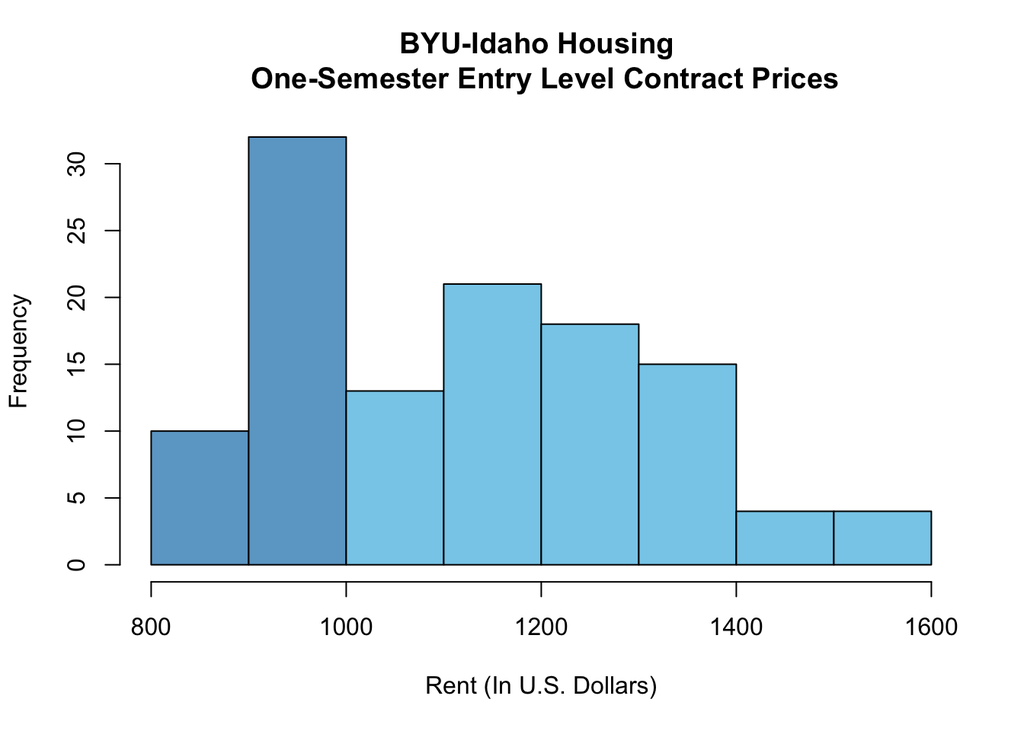

```r
hist(Rent$Price, xlab="Rent (In U.S. Dollars)", main="BYU-Idaho Housing \n One-Semester Entry Level Contract Prices", col=c("skyblue3","skyblue3","skyblue","skyblue","skyblue","skyblue","skyblue","skyblue"))
```

This plot shows a fair percentage of apartments have entry level contracts ranging between $\$800$ and $\$1000$ a semester. This is shown in the graphic above by the dark blue bars. However, there are still a fair number of apartments above $\$1000$. In fact, half of the available entry price rental options cost more than the median price of $\$1120$, as shown in the table below. The cheapest available option is $\$850$ while the most expensive is $\$1585$. The following table summarizes this information as well as the pricing for the high end options, such as what people would pay for a private room, for each complex.

```r
outputTable <- rbind(Price=favstats(Rent$Price), `High Price`=favstats(Rent$PrivateRoomPrice))
pander(outputTable[c("min","Q1","median","mean","Q3","max","n")], caption="BYU-Idaho One-semester Rent Contract Price Summary")
```

BYU-Idaho One-semester Rent Contract Price Summary

|  | min | Q1 | median | mean | Q3 | max | n |
| --- | --- | --- | --- | --- | --- | --- | --- |
| **Price** | 850 | 981 | 1120 | 1133 | 1268 | 1585 | 117 |
| **High Price** | 850 | 995 | 1150 | 1165 | 1310 | 1669 | 117 |

```r
# Note that the options you can select from are
# "min" "Q1"    "median"    "Q3"    "max"   "mean"  "sd"    "n" "missing"
# removing the [,c(...)] from favstats(...) would give all of the options.
```

As shown in the plot below however, it does not appear that there is any strong relationship between the rent cost of an apartment and how far the apartment is from campus. This is good news however, as there are apartments in all price ranges that are close to campus.

```r
plot_ly(Rent) %>%
  add_markers(y= ~Price, x= ~MilesToCampus, text= ~Apartment, color= ~Gender) %>%
  layout(title="2018 BYU-Idaho Housing", xaxis=list(title="Distance from Manwaring Center"), yaxis=list(title="One-Semester Entry Level Contract Prices"))
```

[interactive chart not shown]

#### Interpretation

Note that this analysis does not consider the number of students that are housed in a given apartment. This is certainly an important factor in deciding the true cost of student housing at BYU-Idaho. However, the goal of this analysis was simply to understand the per student cost of housing at BYU-Idaho for single students.